# Sampler benchmark report

## Run and samplers

- **Status:** COMPLETED; 96/96 fits completed successfully. 0 failed; 0 pending; 0 with recorded warnings.
- **Run:** local profile; 2 datasets per scenario.
- **Sampling budget:** 4 sequential chains; 250 warmup + 500 sampling iterations per chain; thin = 1.
- **Runtime:** 38.5 minutes of fitting and 7.7 minutes of evaluation for completed fits. Failed-fit time is not included.
- **Started:** 2026-09-10 19:23:31 UTC. **Overview generated:** 2026-09-11 09:02:59 UTC.
- **Samplers:** Current batchieR Gibbs sampler; Gibbs factor order CMI; Gibbs factor order ICM; Gibbs factor order IMC; Gibbs factor order MCI; Gibbs factor order MIC.
- **Detailed results:** CSV downloads retain every fit and quantity; keep them beside the HTML when sharing download links.

**Sampler descriptions and update strategies**

- **Current batchieR Gibbs sampler** (gibbs)

  1. Mean

  2. Cell offsets

  3. Treatment offsets

  4. Cell factors

  5. Interaction factors

  6. Main treatment factors

  7. Hyperparameters

  8. Observation precision

  Each chain uses the package’s zero-initialized component values and default precision initialization, with an independent RNG stream. This is the unmodified fit_combo() baseline.

- **Gibbs factor order CMI** (gibbs_cmi)

  1. Mean

  2. Cell offsets

  3. Treatment offsets

  4. Cell factors

  5. Main treatment factors

  6. Interaction factors

  7. Hyperparameters

  8. Observation precision

  Only factor block order differs from baseline; entity traversal, conditional updates, zero-initialized component values, default precision initialization, and independent chain RNG streams are unchanged.

- **Gibbs factor order ICM** (gibbs_icm)

  1. Mean

  2. Cell offsets

  3. Treatment offsets

  4. Interaction factors

  5. Cell factors

  6. Main treatment factors

  7. Hyperparameters

  8. Observation precision

  Only factor block order differs from baseline; entity traversal, conditional updates, zero-initialized component values, default precision initialization, and independent chain RNG streams are unchanged.

- **Gibbs factor order IMC** (gibbs_imc)

  1. Mean

  2. Cell offsets

  3. Treatment offsets

  4. Interaction factors

  5. Main treatment factors

  6. Cell factors

  7. Hyperparameters

  8. Observation precision

  Only factor block order differs from baseline; entity traversal, conditional updates, zero-initialized component values, default precision initialization, and independent chain RNG streams are unchanged.

- **Gibbs factor order MCI** (gibbs_mci)

  1. Mean

  2. Cell offsets

  3. Treatment offsets

  4. Main treatment factors

  5. Cell factors

  6. Interaction factors

  7. Hyperparameters

  8. Observation precision

  Only factor block order differs from baseline; entity traversal, conditional updates, zero-initialized component values, default precision initialization, and independent chain RNG streams are unchanged.

- **Gibbs factor order MIC** (gibbs_mic)

  1. Mean

  2. Cell offsets

  3. Treatment offsets

  4. Main treatment factors

  5. Interaction factors

  6. Cell factors

  7. Hyperparameters

  8. Observation precision

  Only factor block order differs from baseline; entity traversal, conditional updates, zero-initialized component values, default precision initialization, and independent chain RNG streams are unchanged.

Details: settings CSV · samplers CSV · status CSV.

## Screen and generating scenarios

The question is whether changing the order of component updates produces more effective posterior draws for the same computation. A scenario specifies both how synthetic responses are generated and which model is fitted. We compare samplers on the same dataset within a scenario, rather than assigning each sampler a different scenario.

**Screen setup**

- **Screen:** 4 cells; 24 drug-dose treatments; 1104 observations; 144 plates per dataset. **Fitted rank:** 4.
- **Matched priors:** generating and fitted priors are identical within each matched-prior scenario, with intercept logit(0.8) and Gamma(25, rate=1) observation precision.
- **Observation masks:** singles are observed first, then nested 25% and 75% subsets of combination plates are revealed independently of responses. Actual observed row counts are in designs.csv.

**Generating scenarios**

- **Gamma:** Draw Gaussian component parameters with Gamma(3, rate=0.3) precision priors, then generate noisy responses. Fit using those same priors. This supplies a relatively simple shrinkage setting for comparing update orders.
- **Multiplicative gamma:** Generate and fit with Gamma component precisions plus multiplicative-gamma cell-factor shrinkage. This changes the dependence and shrinkage across latent dimensions. Its responses are generated separately from the Gamma scenario.
- **Default shrinkage:** Draw parameters and responses using package-default component shrinkage, including horseshoes and multiplicative-gamma cell factors; fit with those same priors. The resulting large signals make this a demanding prior-based test, rather than a realistic screen.
- **Controlled realism:** Construct rank-2, dose-weighted signals at prescribed moderate scales, with observation-noise SD 0.2, instead of drawing the component parameters from the fitted priors. Fit at the configured rank using default component shrinkage. Thus this scenario also tests the default fitted prior, but on controlled data. These are synthetic assumptions; this track supports mixing, recovery and prediction comparisons, not formal SBC.

Gamma, multiplicative gamma and default shrinkage are matched-prior scenarios: generating and fitted priors agree within each scenario, which permits SBC across independently generated datasets. They do not share response values across scenarios. Controlled realism answers a different question: how well does the sampler work on a deliberately moderate synthetic signal?

**How the comparison works**

1. Generate each dataset once, saving the true latent means and interaction effects for later recovery checks.
2. Give every sampler the same nested 25% and 75% observation masks. Unrevealed responses are withheld from fitting and used to assess prediction.
3. Fit every selected sampler to each dataset and mask with the same fitted model and sampling budget, using paired fitting seeds. For the six update-order adapters, initialization and conditional updates are also shared; only the factor-block order changes. Paired seeds do not imply identical random draws after different update orders consume them.
4. Compare R-hat and bulk ESS first, then ESS per fitting second. Recovery and held-out prediction help identify inaccurate fits. A faster fit with poor chain agreement is not evidence of a better posterior sampler.

This run schedules **96 fits**: 2 datasets per scenario × 4 scenarios × 2 observation masks × 6 samplers. The two masks reuse each generated dataset; they are not independent dataset replications.

Details: designs CSV.

## Mixing and efficiency

Details: efficiency summary CSV · diagnostics CSV · paired comparisons CSV.

Bars show the mean across datasets within each scenario, mask and sampler; error bars show one SD, not confidence intervals. Scales are fixed across panels within each figure.

**1247 / 1728 quantity–fit R-hat values exceed 1.01 or are unavailable.** The first figure summarizes each fit’s maximum R-hat. Non-finite values are counted here and omitted from the plot; the dashed line is 1.01.

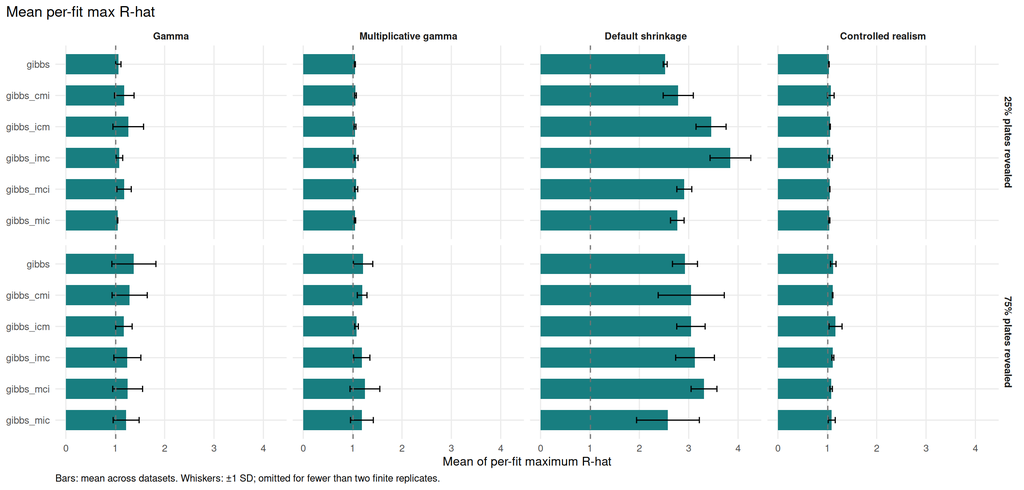

Bulk ESS is summarized within each fit by the median across monitored quantities, then averaged across datasets. The dashed line marks 100, the current SBC minimum for each quantity; a median above 100 does not establish adequacy for every quantity. **625 / 1728 quantity–fit results have bulk/tail ESS below 100 or unavailable.**

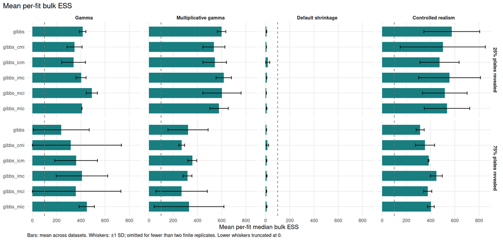

Bulk ESS per fitting second uses the same per-fit median ESS, divided by total fitting time including initialization and warmup, then averaged across datasets. Higher is better; poorly converged fits remain included, so efficiency alone does not establish correctness.

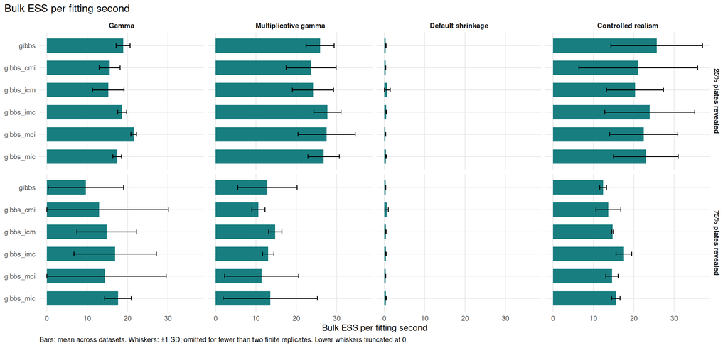

**Selected chain traces**

Fixed example: first dataset, first scenario and mask, reference sampler. No selection by apparent mixing quality. All monitored draws remain in `fits/*.rds`.

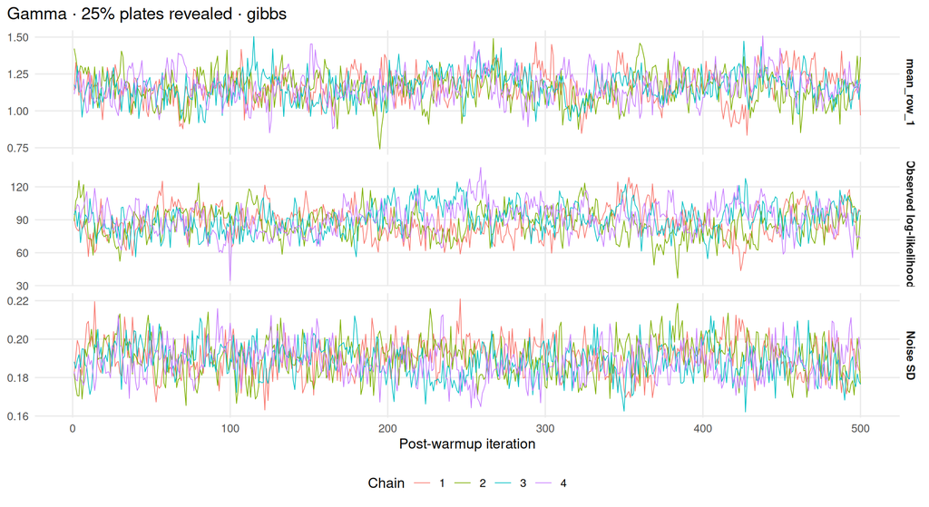

## Recovery and prediction

This section checks whether sampler choices affect recovery of the known generating signals and prediction of held-out responses. For a fixed dataset and fitted model, correct Gibbs update orders preserve the same target posterior; their mixing and finite-run Monte Carlo error can differ.

Similar RMSE and coverage provide useful consistency checks, but do not establish that the full posterior distributions agree. Generating truth is a recovery target, not an exact posterior reference. Agreement of posterior summaries within their Monte Carlo uncertainty would require a separate comparison, particularly when R-hat and ESS indicate poor convergence.

The response-scale figure shows the generated data shared by all samplers within each scenario. It provides context for the size of the recovery errors; it does not display posterior draws.

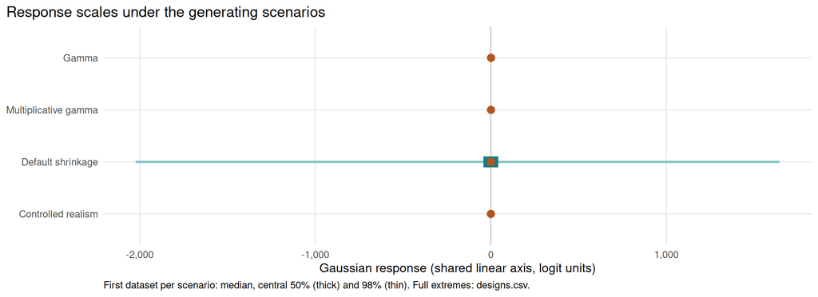

- **Default-prior scale:** responses span -9135 to 16156; on average 89.6% of viabilities are below 0.01 or above 0.99. Unit-scale global/local half-Cauchy priors allow large drug factors, and interactions multiply two drug factors. This scenario tests the default prior’s tails; it is not a realistic-screen calibration.
- **Boundary responses:** across datasets, an average 22.5% of simulated viabilities lie below 0.01 or above 0.99. Extreme finite draws are retained.
- **Comparability:** compare candidate samplers within the same scenario and mask. Raw efficiency and errors across priors describe different inference problems.

Details: designs CSV · metrics CSV · coverage CSV.

Latent-mean recovery and held-out response prediction are compared on the same Gaussian logit-response scale. Lower RMSE is better. Rows separate 25% and 75% revealed plates; columns separate generating scenarios. Colors distinguish latent means and held-out responses. Viability metrics, interaction recovery and all interval levels remain in the CSVs.

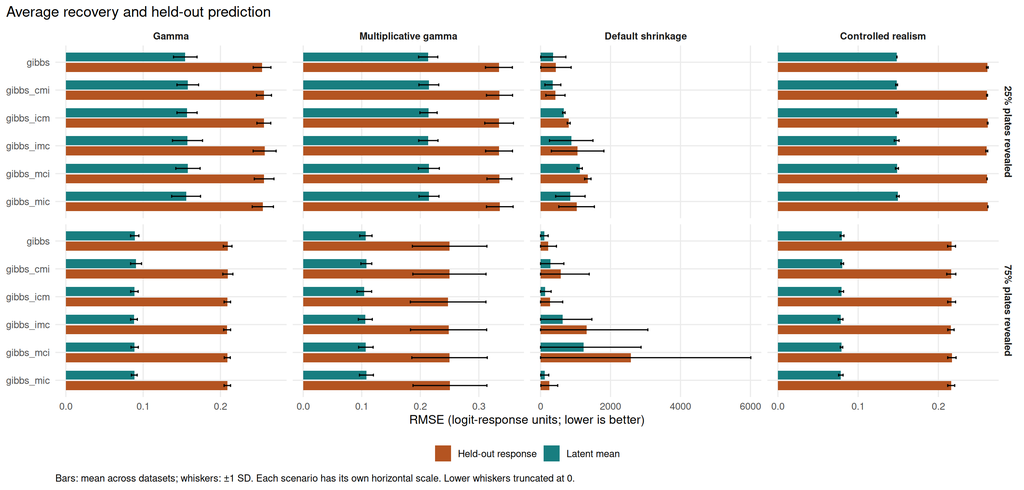

95% interval coverage uses the same targets and layout, with nominal coverage marked by a dashed line. Whiskers show variability across datasets, not uncertainty from treating rows within a screen as independent. Whiskers are not clipped to [0,1]. Controlled realism is reported separately from matched-prior scenarios.

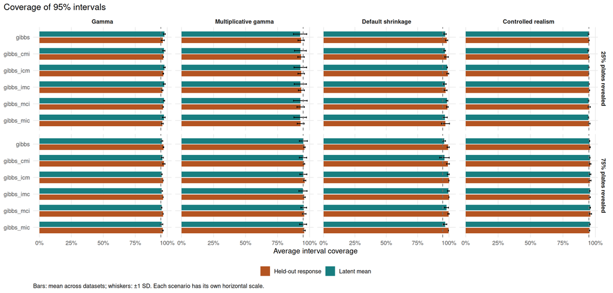

## Simulation-based calibration

Details: ranks CSV · rank summary CSV · ecdfs CSV.

**Exploratory run: this profile cannot establish calibration.**

**Panels with failed, pending, or ineligible datasets are inconclusive: the successful subset may be selected.** The realism track is not matched-prior SBC. No automatic calibration-pass claim is made.

Recorded quantity–dataset ranks: eligible: 274; inadequate convergence or ess: 944; not matched prior: 432; residual autocorrelation: 78.

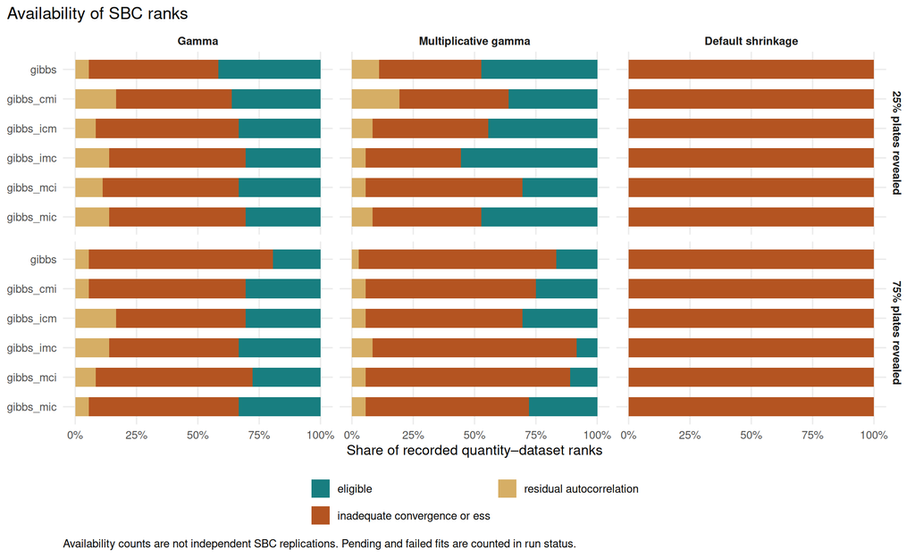

Rank plots show the reference sampler (gibbs) and two fixed quantities: noise SD and observed-data log-likelihood. Each panel contains one rank per independent dataset; quantities and masks are never pooled. Other samplers and quantities remain in the CSVs.

No eligible ranks for the selected overview quantities. Other available ranks are in the CSVs.

**Selected rank histograms**

Unavailable: no eligible ranks for the selected overview quantities.

**SBC method and current eligibility rule**

Ranks use M=100 temporally spaced draws. Eligibility requires full-chain R-hat <=1.01, bulk and tail ESS >=100, and basic ESS >=90% of the balanced spaced sample size. The small-sample ESS gate is noisy; these checks do not prove independence. No adaptive extension is used. Fixed constants are excluded and ties randomized reproducibly. Bands use 10,000 discrete-uniform simulations. Observed-data log-likelihood includes Gaussian normalization and exactly the observed rows.

## Self-checks, failures, and reproducibility

The analytic self-checks assess whether the benchmark can recognize known sampling errors in a simple problem with an exact answer. We simulate a normal mean with a standard-normal prior and 20 observations with known variance 1, then compare exact posterior draws with three deliberately incorrect alternatives: draws from the prior, a shifted posterior, and an artificially narrow posterior. These reference adapters are separate from the combination-model samplers and are excluded from efficiency comparisons.

For each alternative, we calculate SBC ranks for both the mean parameter and the observed-data log-likelihood. The figure shows the largest absolute difference between the empirical rank CDF and the expected discrete-uniform CDF; the dashed line is the 95% simultaneous-envelope threshold for each quantity. Prior-only draws can have uniform parameter ranks despite ignoring the data, which is why the likelihood check matters. The self-check outcome assesses sensitivity to the deliberate errors and checks for gross departures in the exact reference; crossing a 95% envelope alone does not make a correct reference fail. These checks exercise the rank and envelope calculations, but do not validate the combination-model sampler or its convergence and SBC draw-eligibility rules.

The remaining records distinguish execution problems from statistical adequacy. Failed or pending fits and recorded warnings appear in the status file; a completed fit without warnings can still have poor R-hat or ESS, as shown in the earlier sections. Saved settings, seeds, software versions, and source fingerprints document how the numerical results were produced. They allow compatible runs to resume and reports to be regenerated from saved results without repeating inference.

Details: self checks CSV · status CSV · versions CSV · source fingerprints CSV.

**Analytic harness self-check:** passed. These check the benchmark reference problem, not the candidate sampler’s calibration.

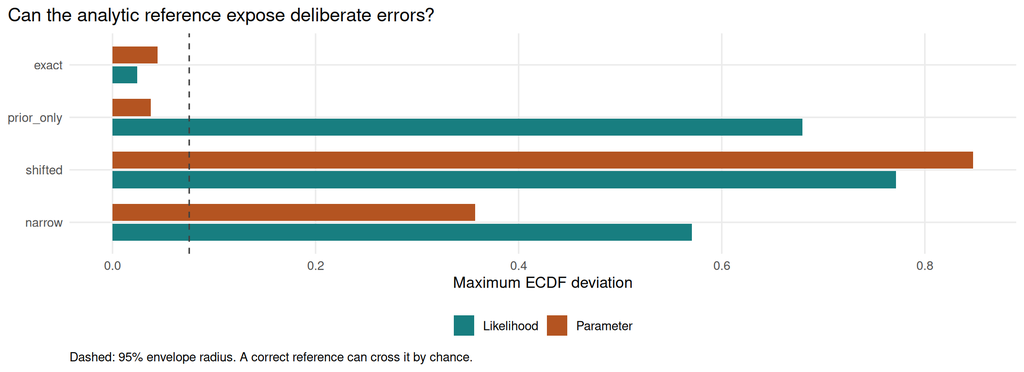

**0 fits need attention.** Full errors, warnings and pending jobs are in status.csv.

No failed or pending fits and no recorded fitting warnings.

Averages can hide difficult datasets; inspect convergence and failure counts before comparing speed. Fast mixing, recovery and SBC alone do not prove correctness. Selection of plots is fixed, not based on favorable ranks.

- **R:** R version 4.6.1 (2026-06-24).
- **Platform:** x86_64-pc-linux-gnu.
- **Quarto:** 1.9.38.
- **Master seed:** 20260910.

Configuration and original sampling provenance are retained in `manifest.rds`; compact draws and fitting seeds are in `fits/*.rds`. Report regeneration reads saved results and performs no fitting.

Methods: [Stan SBC guidance](https://mc-stan.org/docs/stan-users-guide/simulation-based-calibration.html); [Modrák et al., choice of SBC test quantities](https://arxiv.org/abs/2211.02383).